# R Notebook

# Nashville Tennessee Data

This will be the h3 hash generation work for Nashville, Tennessee. The other city notebooks follow the same steps but with different sets of CBSA data.

Estimated time to run: 1 hour?

Load packages:

```r
library(ggplot2)
library(glue) # Interpreted String Literals
library(h3)
library(here) # A Simpler Way to Find Your Files
library(osmdata) # package for working with streets
library(sf) # Simple Features for R
library(tidycensus) # Load US Census Boundary and Attribute Data as 'tidyverse' and 'sf'-Ready Data Frames
library(tidyverse) # Easily Install and Load the 'Tidyverse'
library(tigris) # Load Census TIGER/Line Shapefiles
```

## Network data

Download OSM data for Nashville [here](https://download.geofabrik.de/north-america/us/tennessee.html). It will be a proto-buffer file (pbf). Save under `data-raw/r5_graph`.

## Census tracts

Obtain the census tracts for Nashville. Note that [{tidycensus}](https://walker-data.com/tidycensus/) function `get_decenial()` allows the selection of state and county, but not metro area or city. Check the example [here](https://walker-data.com/census-r/spatial-analysis-with-us-census-data.html#identifying-geometries-within-a-metropolitan-area) to see how to select tracts in a city.

```r
options(tigris_use_cache = TRUE)

tn_tracts <- get_decennial(geography = "tract",
                           variables = "H1_001N",
                           state = "Tennessee",
                           year = 2020,
                           geometry = TRUE
)
```

```
Using the PL 94-171 Redistricting Data Summary File
```

```r
tn_city <- urban_areas(year = 2020) |>
  filter(str_detect(NAME10, "TN"))
```

A [core-based statistical area](https://en.wikipedia.org/wiki/Core-based_statistical_area) is a generous definition of the area of interest, since it contains an urban nucleus and also all neighboring communities that are tightly integrated with it. It is important to note that some of the neighboring communities share boundaries with the urban nucleus, but some are disconnected.

```r
nashville_cbsa <- core_based_statistical_areas(year = 2020) |>
  filter(str_detect(NAME, "Nashville"))
```

A much stricter definition of the area of interest would result from using the city boundaries, which can be obtained using `urban_areas()`:

```r
nashville_city <- urban_areas(year = 2020) |>
  filter(str_detect(NAME10, "Nashville"))
```

Plot:

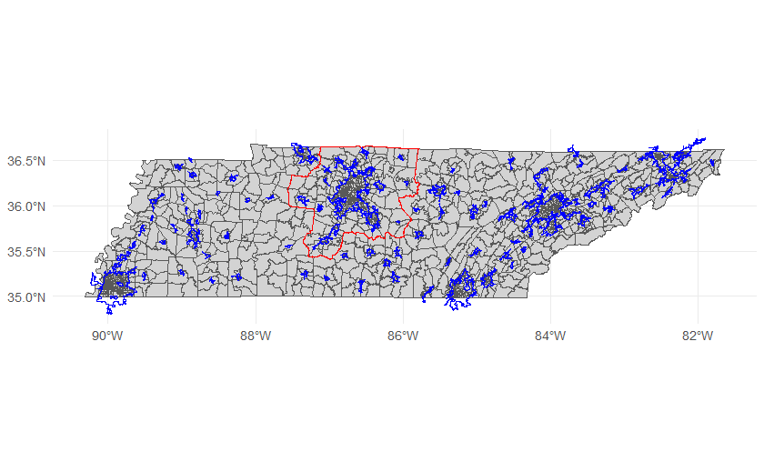

```r
ggplot() +
  geom_sf(data = tn_tracts,
          fill = "lightgrey") +
  geom_sf(data = nashville_cbsa,
          color = "red",
          fill = NA) +
  geom_sf(data = tn_city,
          color = "blue",
          fill = NA) +
  theme_minimal()
```

Select all urban areas in Nashville CBSA:

```r
nashville_urban <- st_filter(tn_city, nashville_cbsa)
```

Plot urban boundaries within the Nashville CBSA:

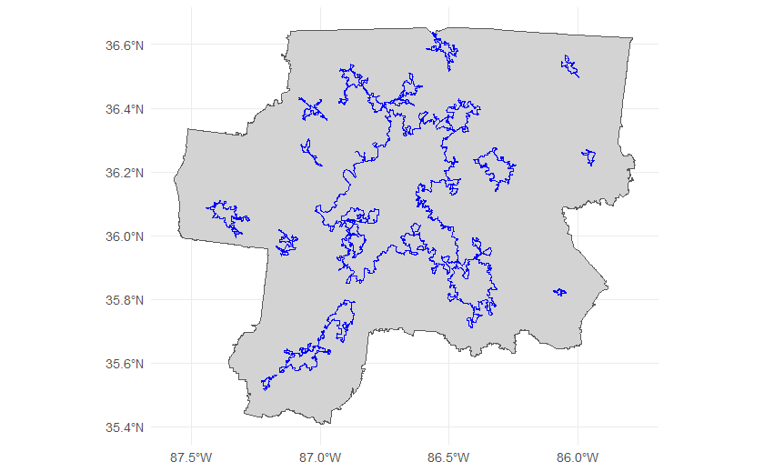

```r
ggplot() +
  geom_sf(data = nashville_cbsa,
          fill = "lightgray") +
  geom_sf(data = nashville_urban,
          color = "blue",
          fill = NA) +
  theme_minimal()
```

Obtain the Nashville tracts:

```r
nashville_tracts <- tn_tracts |>
  st_intersection(nashville_urban)
```

Plot Nashville’s urban tracts within the CBSA:

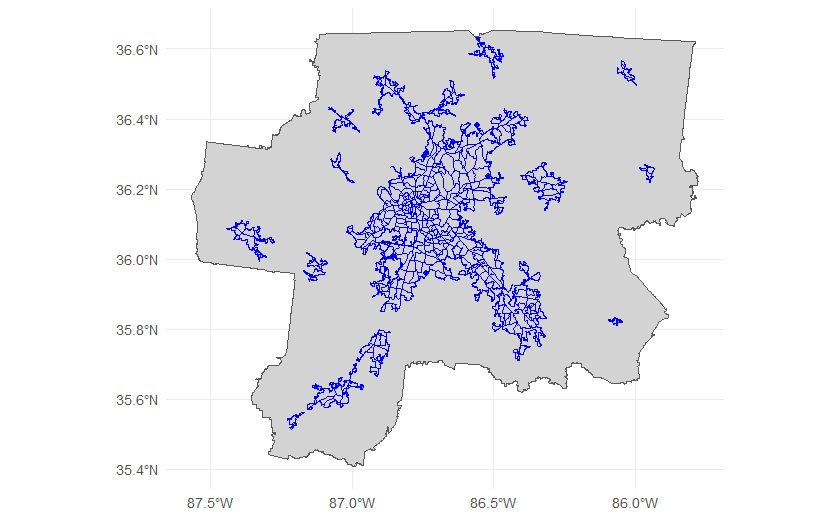

```r
ggplot() +
  geom_sf(data = nashville_cbsa,
          fill = "lightgray") +
  geom_sf(data = nashville_tracts,
          color = "blue",
          fill = NA) +
  theme_minimal()
```

## Geohashes

Use the centroid of Nashville CBSA and Nashville coordinates from OSM’s website to obtain h3 polygons:

```r
coords <- st_centroid(nashville_cbsa) |>
  st_coordinates()
print(coords)
```

```
             X        Y
[1,] -86.64592 36.11897
```

Retrieve h3 geohashing at a fairly high resolution to identify Nashville:

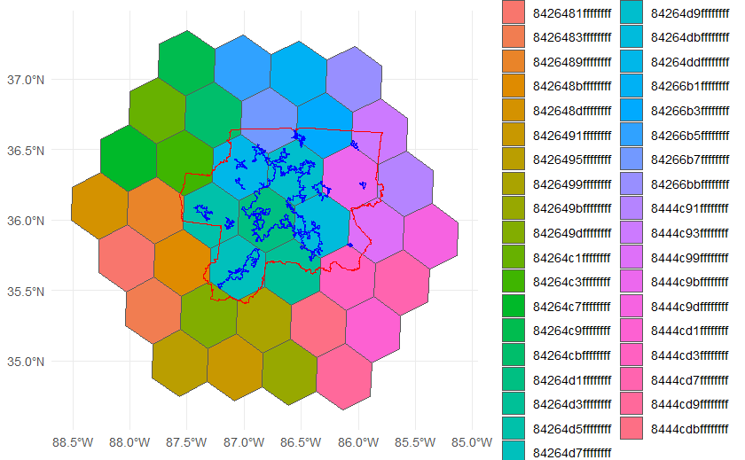

```r
nashville_h3 <- geo_to_h3(c(36.11897, -86.64592),
                             res = 4) |>

# 36.178, -86.731

# nashville coordinates were taken from the generated coords in the line above (but the order is reversed) and are kept at 5 decimal points.

  k_ring(3)

# k_ring sets the number of h3 rings to generate around the initial h3 point, typically 2 or 3 are required depending on the CBSA.

ggplot() +
  geom_sf(data = (h3_to_geo_boundary_sf(nashville_h3)),
          aes(fill = h3_index)) +
    geom_sf(data = nashville_cbsa,
          color = "red",
          fill = NA) +
  geom_sf(data = nashville_urban,
          color = "blue",
          fill = NA) +
  theme_minimal()
```

```r
# fill = h3_index

print.listof(h3_to_geo_boundary_sf(nashville_h3))
```

```
h3_index :
 [1] "84264d1ffffffff" "84264ddffffffff" "84264d5ffffffff" "84264d7ffffffff"
 [5] "84264d3ffffffff" "84264dbffffffff" "84264d9ffffffff" "84266b7ffffffff"
 [9] "84264cbffffffff" "84264c3ffffffff" "8426489ffffffff" "842648bffffffff"
[13] "842649dffffffff" "8426499ffffffff" "8444cdbffffffff" "8444cd3ffffffff"
[17] "8444c99ffffffff" "8444c9bffffffff" "84266b3ffffffff" "84266b1ffffffff"
[21] "84266b5ffffffff" "84264c9ffffffff" "84264c1ffffffff" "84264c7ffffffff"
[25] "842648dffffffff" "8426481ffffffff" "8426483ffffffff" "8426495ffffffff"
[29] "8426491ffffffff" "842649bffffffff" "8444cd9ffffffff" "8444cd1ffffffff"
[33] "8444cd7ffffffff" "8444c9dffffffff" "8444c91ffffffff" "8444c93ffffffff"
[37] "84266bbffffffff"

geometry :
Geometry set for 37 features
Geometry type: POLYGON
Dimension:     XY
Bounding box:  xmin: -88.51438 ymin: 34.6509 xmax: -85.12232 ymax: 37.34721
Geodetic CRS:  WGS 84
First 5 geometries:
```

```
POLYGON ((-86.81177 35.76625, -86.56658 35.8662...
POLYGON ((-87.04204 36.1373, -86.79562 36.23719...
POLYGON ((-87.29559 35.8004, -87.04959 35.90156...
POLYGON ((-87.06458 35.429, -86.81979 35.53025,...
POLYGON ((-86.58367 35.3948, -86.3397 35.4949, ...
```

Keep only the h3 indices that overlap with the urban areas within the Nashville CBSA:

```r
nashville_h3 = c("84264d1ffffffff", "84264ddffffffff", "84264d5ffffffff", "84264d7ffffffff", "84264d3ffffffff", "84264dbffffffff", "84264d9ffffffff", "84266b7ffffffff", "8444cd3ffffffff",  "8444c99ffffffff", "8444c9bffffffff", "84266b3ffffffff", "8444c93ffffffff")

# Can be done through trial and error (take all h3 codes from the generated list and remove one-by-one, or remove based on h3 numbers as they go in a spiral from 1-37)
```

Plot kept indices:

```r
ggplot() +
  geom_sf(data = h3_to_geo_boundary_sf(nashville_h3),
          aes(fill = h3_index)) +
  geom_sf(data = nashville_cbsa,
          color = "red",
          fill = NA) +
  geom_sf(data = nashville_urban,
          color = "blue",
          fill = NA) +
  theme_minimal()
```

[output not shown]

Obtain children hashes at a higher resolution (8):

```r
nashville_h3 <- nashville_h3 |>
  purrr::map(\(x) h3_to_children(x, res = 8)) |>
  unlist()
```

```r
nashville_h3 <- h3_to_geo_boundary_sf(nashville_h3) |>
  st_transform(crs = st_crs(nashville_urban)) |>
  st_intersection(nashville_urban)

nashville_h3 <- nashville_h3 |>
  pull(h3_index)
```

Plot:

```r
ggplot() +
  geom_sf(data = h3_to_geo_boundary_sf(nashville_h3)) +
  geom_sf(data = nashville_cbsa,
          color = "red",
          fill = NA) +
  geom_sf(data = nashville_urban,
          color = "blue",
          fill = NA) +
  theme_minimal()
```

[output not shown]

Currently this is resolution 8:

```r
h3_get_resolution(nashville_h3)
```

[output not shown]

Obtain children at resolution 13 (average area is ~42.45 $m^2$):

```r
nashville_h3 <- nashville_h3 |>
  purrr::map(\(x) h3_to_children(x, res = 13)) |>
  unlist()
```

Check the size of an h3 hexagon:

```r
sample_h3 <- h3_to_geo_boundary_sf(nashville_h3[1])

sample_h3 |>
  mutate(area = st_area(geometry))
```

[output not shown]

Information about housing characteristics. Explore the tables [here](https://data.census.gov/advanced?q=Housing) to get a sense of the variables that might be interesting to date the housing stock. For example, a search within the topic of “housing” shows that there is a set of variables with “physical characteristics”. The keywords for age of housing stock are “year” and “structure”. Next, use {tidycensus} to explore the variables available:

```r
v17 <- load_variables(2022,
                      "acs5",
                      cache = TRUE)


v17 |>
  filter(str_detect(concept, "Year") & str_detect(concept, "Structure"))
```

Refine the search:

```r
v17 |>
  filter(str_detect(label, "Estimate!!Total:!!Built"))
```

```r
housing_block_group_tn <- get_acs(geography = "cbg",
                               state = "TN",
                               variables = v17 |>
                                 filter(str_detect(label, "Estimate!!Total:!!Built")) |>
                                 pull(name),
                               year = 2022,
                               geometry = TRUE)

#trying to add "state = c("AZ", "TX", "TN", "GE", "LA")" did not work, so I am making all the housing block groups separate.
```

```r
housing_block_group_tn <- housing_block_group_tn |>
  st_intersection(nashville_urban)
```

The proportion of buildings built during certain periods could be a good indicator of post-war suburban development.

Save data objects:

```r
# Tracts
save(nashville_tracts,
     file = glue::glue(here::here(),
                       "/data-raw/nashville_tracts.rda"),
     compress = "bzip2")
# Urban boundaries
save(nashville_urban,
     file = glue::glue(here::here(),
                       "/data-raw/nashville_urban.rda"),
     compress = "bzip2")
# CBSA boundary
save(nashville_cbsa,
     file = glue::glue(here::here(),
                       "/data-raw/nashville_cbsa.rda"),
     compress = "bzip2")

# h3 identifiers from which the coordinates can be retrieved for routing
save(nashville_h3,
     file = glue::glue(here::here(),
                       "/data-raw/nashville_h3.rda"),
     compress = "bzip2")

# h3 identifiers from which the coordinates can be retrieved for routing
save(housing_block_group_tn,
     file = glue::glue(here::here(),
                       "/data-raw/housing_block_group_tn.rda"),
     compress = "bzip2")
```